# GAE10: PCA & NMDS

### Results

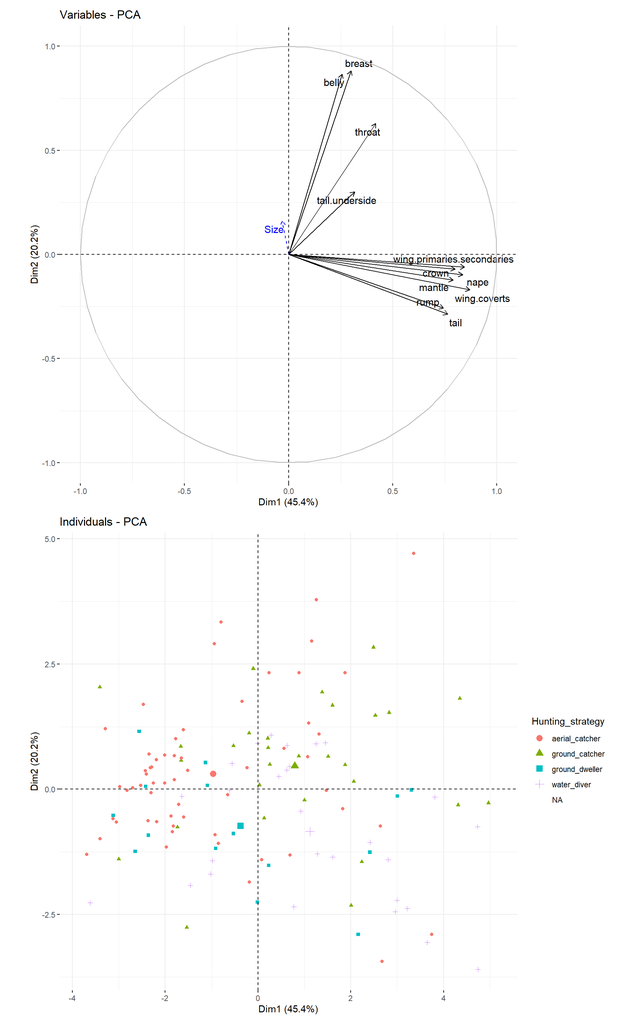

Figure 2: Variable and individual PCA’s of color differences among birds based on their hunting strategies.

## Scenario 2: Deer and Forest Plant Communities

White-tailed deer (*Odocoileus virginianus*) are often considered to be keystone species in forest communities. Sabo et al. (2017) conducted surveys of the vegetation and environmental conditions of deer exclusion plots and adjacent plots outside the exclusion areas as part of a larger study to examine the indirect effects of their presence on the plant assemblages.

### Methods:

In Summer 2011, the researchers visited 17 deer exclosures in upland forests of northern Wisconsin and Michigan’s Upper Peninsula (UP) that were constructed for various previous studies between 1991 and 2002. In each stand, they sampled vegetation and measured key environmental variables inside the fences and in paired ‘deer-access’ plots outside the fences. The latter were in close proximity to the exclosures (always within 100 m), and were placed in locations with similar management histories and overstory structure and composition. Within each exclosure and control area, multiple quadrats were sampled and they recorded the incidence of all herbaceous, shrub, and tree seedling species.

### Results

Table 1: PERMANOVA to test for a difference in plant assemblages between deer exclusion areas and adjacent areas

|  | df | SS | $R^2$ | F | P |
| --- | --- | --- | --- | --- | --- |
| Treatment | 1 | 0.115 | 0.011 | 0.343 | 0.988 |
| Residual | 32 | 10.714 | 0.989 |  |  |
| Total | 33 | 10.829 | 1.000 |  |  |

## References:

Babarović, F., C. R. Cooney, Z. K. Varley, L. O. Nouri, N. J. Nadeau, and G. H. Thomas. 2023. [The effects of ecology and behavior on the evolution of coloration in Coraciiformes](https://doi.org/10.1093/beheco/arad008). Behavioral Ecology 34:387–398.

Cooney, C. R., Z. K. Varley, L. O. Nouri, C. J. A. Moody, M. D. Jardine, and G. H. Thomas. 2019. [Sexual selection predicts the rate and direction of colour divergence in a large avian radiation](https://doi.org/10.1038/s41467-019-09859-7). Nature Communications 10:1773.

Sabo, A. E., K. L. Frerker, D. M. Waller, and E. L. Kruger. 2017. [Deer-mediated changes in environment compound the direct impacts of herbivory on understorey plant communities](https://doi.org/10.1111/1365-2745.12748). Journal of Ecology 105:1386–1398.